# Introduction to Model Comparison

## Underfitting and overfitting

**Occam’s Razor**: Models with fewer assumptions are preferred

- How should we designate “preferred?”
- How should we compare among them?
- How good is good enough?

[figure not shown]

## Tradeoff in model specification

**Underfitting**: Model doesn’t describe the observed sample *well enough*.

- Leads to poor prediction

**Overfitting**: Model describes the observed sample *too well*.

- Leads to poor prediction

We need to find a balance between *regular* features (what we want to model) and *irregular* features (noise we want to ignore).

## Why do we make models?

- Estimates of the magnitudes of parameters and/or differences between parameter estimates, *and* their relative precision
- Hypothesis testings, etc.

No model represents the true biological process

- This is actually a good thing.
- Which model comes *closest* to the true biological process from a *(small) set of working hypotheses*?

## Brain volume and (estimated) body mass in hominins (*Homo*)

```
##       Species Brain_Vol Mass
## 1   afarensis       438 37.0
## 2   africanus       452 35.5
## 3     habilis       612 34.5
## 4      boisei       521 41.5
## 5 rudolfensis       752 55.5
## 6    ergaster       871 61.0
## 7     sapiens      1350 53.3
```

## Brain volume and body mass in hominins

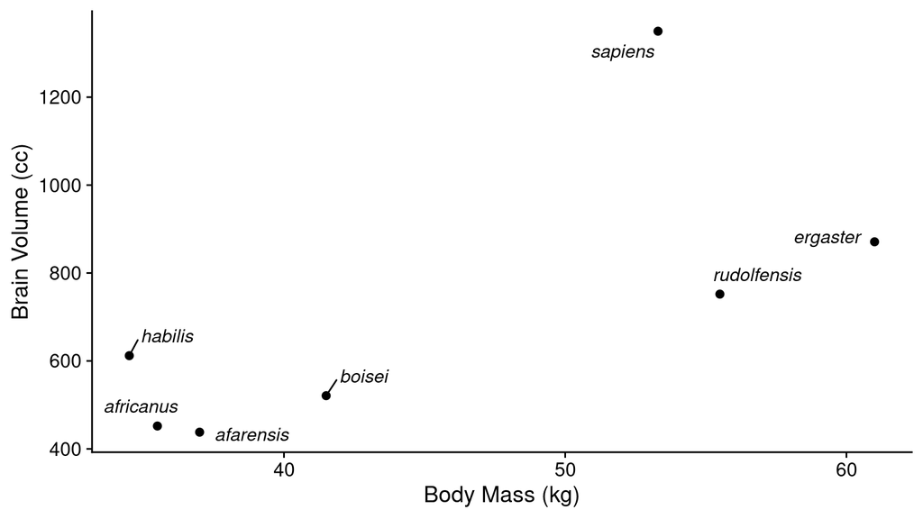

## 6 increasingly complex polynomial models

- \(\mbox{Brain Vol} = \beta_0 + \beta1 \mbox{M}\)
- \(\mbox{Brain Vol} = \beta_0 + \beta1 \mbox{M} + \beta2 \mbox{M}^2\)
- \(\mbox{Brain Vol} = \beta_0 + \beta1 \mbox{M} + \beta2 \mbox{M}^2 + \beta3 \mbox{M}^3\)
- \(\mbox{Brain Vol} = \beta_0 + \beta1 \mbox{M} + \beta2 \mbox{M}^2 + \beta3 \mbox{M}^3 + \beta4 \mbox{M}^4\)
- \(\mbox{Brain Vol} = \beta_0 + \beta1 \mbox{M} + \beta2 \mbox{M}^2 + \beta3 \mbox{M}^3 + \beta4 \mbox{M}^4 + \beta5 \mbox{M}^5\)
- \(\mbox{Brain Vol} = \beta_0 + \beta1 \mbox{M} + \beta2 \mbox{M}^2 + \beta3 \mbox{M}^3 + \beta4 \mbox{M}^4 + \beta5 \mbox{M}^5 + \beta6 \mbox{M}^6\)

Compare *R*<sup>2</sup> among them.

## 1: \(\mbox{Brain Vol} = \beta_0 + \beta_1 \mbox{M}\)

```r
fm1 <- lm(Brain_Vol ~ Mass, data = M)
coef(fm1)
```

```
## (Intercept)        Mass
##  -223.08398    20.60191
```

```r
summary(fm1)$r.squared
```

```
## [1] 0.4838903
```

## 1: \(\mbox{Brain Vol} = \beta_0 + \beta_1 \mbox{M}\)

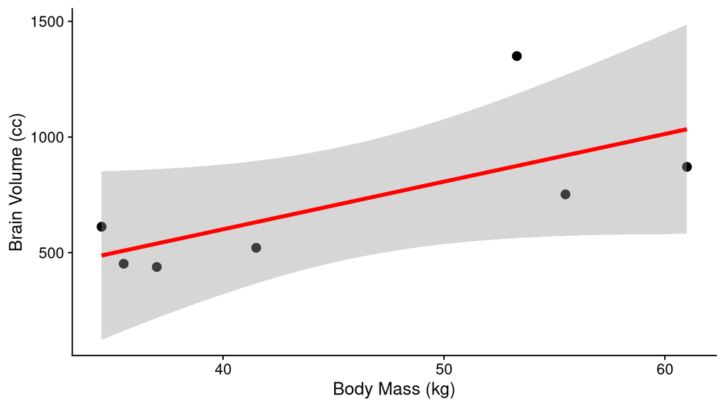

## 2. \(\mbox{Brain Vol} = \beta_0 + \beta_1 \mbox{M} + \beta_2 \mbox{M}^2\)

```r
fm2 <- lm(Brain_Vol ~ Mass + I(Mass ^ 2), data = M)
coef(fm2)
```

```
##  (Intercept)         Mass    I(Mass^2)
## -2715.909694   131.775921    -1.181312
```

```r
summary(fm2)$r.squared
```

```
## [1] 0.5344683
```

## 2. \(\mbox{Brain Vol} = \beta_0 + \beta_1 \mbox{M} + \beta_2 \mbox{M}^2\)

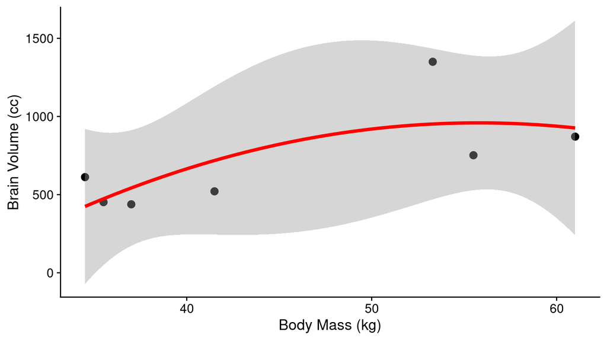

## 3. \(\mbox{Brain Vol} = \beta_0 + ... + \beta_3 \mbox{M}^3\)

```r
fm3 <- lm(Brain_Vol ~ Mass + I(Mass ^ 2) + I(Mass ^ 3), data = M)
coef(fm3)
```

```
##   (Intercept)          Mass     I(Mass^2)     I(Mass^3)
## 21796.9216179 -1463.0423106    32.6245322    -0.2340781
```

```r
summary(fm3)$r.squared
```

```
## [1] 0.676166
```

## 3. \(\mbox{Brain Vol} = \beta_0 + ... + \beta_3 \mbox{M}^3\)

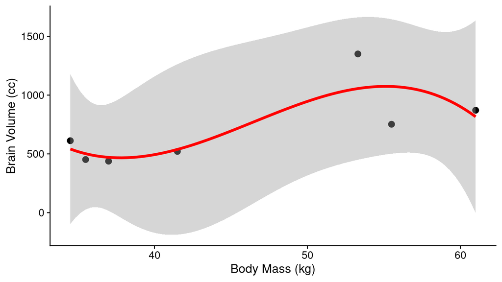

## 4. \(\mbox{Brain Vol} = \beta_0 + ... + \beta_4 \mbox{M}^4\)

```r
fm4 <- lm(Brain_Vol ~ Mass + I(Mass ^ 2) + I(Mass ^ 3) +
            I(Mass ^ 4), data = M)
coef(fm4)
```

```
##   (Intercept)          Mass     I(Mass^2)     I(Mass^3)     I(Mass^4)
##  3.316642e+05 -2.873024e+04  9.181244e+02 -1.280912e+01  6.592707e-02
```

```r
summary(fm4)$r.squared
```

```
## [1] 0.8265487
```

## 4. \(\mbox{Brain Vol} = \beta_0 + ... + \beta_4 \mbox{M}^4\)

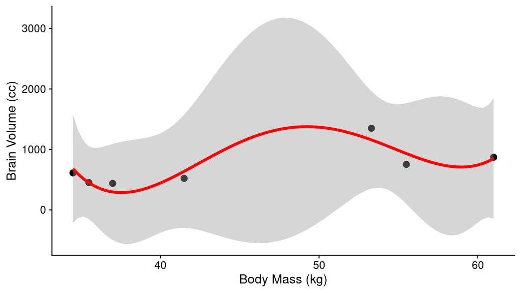

## 5. \(\mbox{Brain Vol} = \beta_0 + ... + \beta_5 \mbox{M}^5\)

```r
fm5 <- lm(Brain_Vol ~ Mass + I(Mass ^ 2) + I(Mass ^ 3) +
            I(Mass ^ 4) + I(Mass ^ 5), data = M)
coef(fm5)
```

```
##   (Intercept)          Mass     I(Mass^2)     I(Mass^3)     I(Mass^4)
## -1.392795e+06  1.636998e+05 -7.583352e+03  1.730186e+02 -1.943354e+00
##     I(Mass^5)
##  8.597088e-03
```

```r
summary(fm5)$r.squared
```

```
## [1] 0.9896316
```

## 5. \(\mbox{Brain Vol} = \beta_0 + ... + \beta_5 \mbox{M}^5\)

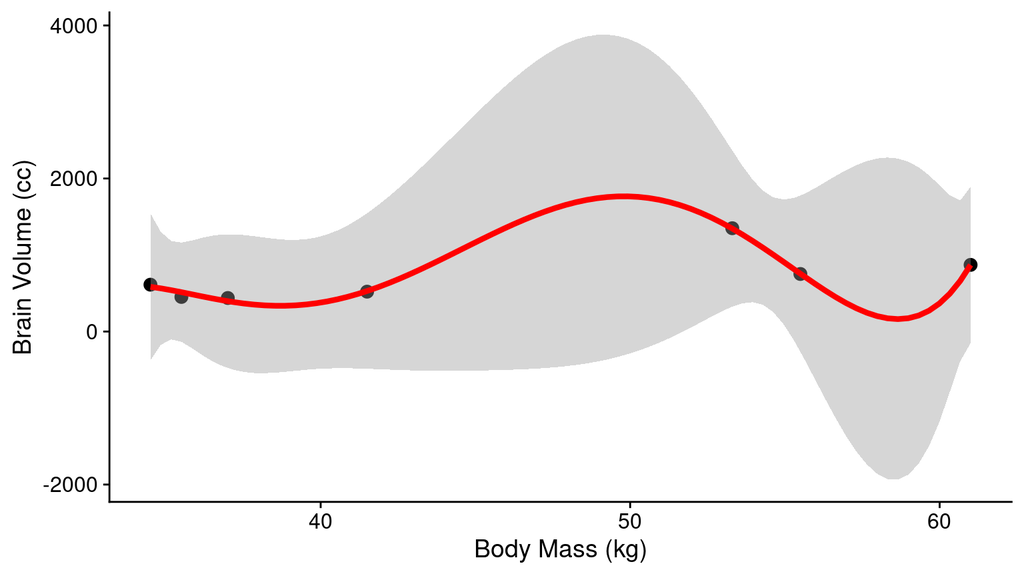

## 6. \(\mbox{Brain Vol} = \beta_0 + ... + \beta_6 \mbox{M}^6\)

```r
fm6 <- lm(Brain_Vol ~ Mass + I(Mass ^ 2) + I(Mass ^ 3) +
            I(Mass ^ 4) + I(Mass ^ 5) + I(Mass ^ 6), data = M)
coef(fm6)
```

```
##   (Intercept)          Mass     I(Mass^2)     I(Mass^3)     I(Mass^4)
##  1.064229e+07 -1.443604e+06  8.103083e+04 -2.408248e+03  3.995668e+01
##     I(Mass^5)     I(Mass^6)
## -3.508001e-01  1.272891e-03
```

```r
summary(fm6)$r.squared
```

```
## [1] 1
```

## 6. \(\mbox{Brain Vol} = \beta_0 + ... + \beta_6 \mbox{M}^6\)

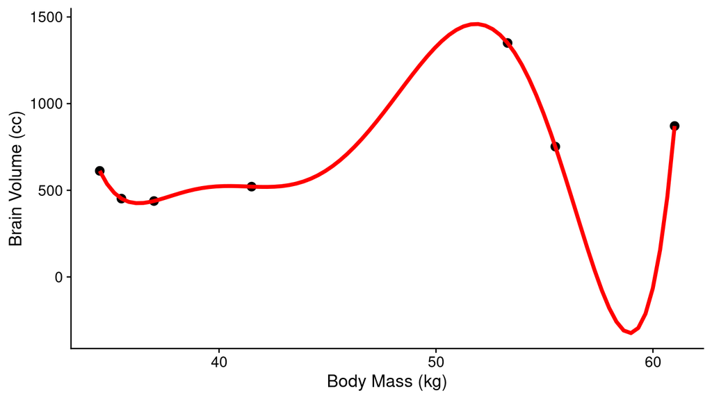

## Summary R<sup>2</sup>

| Model | R<sup>2</sup> |
| --- | --- |
| 1 | 0.48 |
| 2 | 0.53 |
| 3 | 0.68 |
| 4 | 0.83 |
| 5 | 0.99 |
| 6 | 1 |

## Which model(s) balance under- vs. overfitting?

Model 0: Mean only

- Poor *in-sample* prediction
- Poor *out-of-sample* prediction

Model 1: Maybe enough information?

Model 6: Clearly overfit

- Perfect *in-sample* prediction
- Poor *out-of-sample* prediction

## Tradeoff in model specification

> “Overfitting: **fitting is easy; prediction is hard**. Future data will not be exactly like past data, and so any model that is unaware of this fact tends to make worse predictions than it could. So if we wish to make good predictions, we cannot judge our models simply on how well they fit our data. Information criteria provide estimates of predictive accuracy, rather than merely fit. So they compare models where it matters.” (McElreath 2015)

## Methods for model comparison

1. Likelihood ratio tests
2. Information criteria
3. Cross validation

## References

McElreath, R. 2015. *Statistical Rethinking: A Bayesian Course with Examples in R and Stan*. Chapman; Hall/CRC, Boca Raton, FL.